# Biogeographical patterns on quercus and poaceae species across Spain by means of LDA

Eric Bataller

```r
library(sp)
library(raster)
library(rgbif)
library(protolite)
library(tidyverse)
library(quanteda)
library(quanteda.textplots)
library(topicmodels)
library(LDAvis)
library(lda)

library(glue)
library(dplyr)
library(ggplot2)
library(readxl)
library(stringr)
library(colorspace)
library(sf)
set.seed(5528)
```

# 1. Load the shape files of municipalities in spain:

```r
base_dir <- "C:/Users/ericb/Desktop/Stats_final/lineas_limite"

peninbal_shp_filename <- glue("{base_dir}/SHP_ETRS89/recintos_municipales_inspire_peninbal_etrs89/recintos_municipales_inspire_peninbal_etrs89.shp")
canarias_shp_filename <- glue("{base_dir}/SHP_WGS84/recintos_municipales_inspire_canarias_wgs84/recintos_municipales_inspire_canarias_wgs84.shp")

peninbal_shp <- read_sf(peninbal_shp_filename, quiet = TRUE) #This returns an sf-tibble type data (contains polygons)
canarias_shp <- read_sf(canarias_shp_filename, quiet = TRUE)
```

A sf-tibble is similar to a normal tibble, with an entry for each of the territorial units contained in the file (in this case, a municipality). The different columns correspond to properties associated with each province, like, for example, its name or the id code. The last column of a sf-tibble is special, since it must be present in all data files of these type: the so-called geometry, which contains the list of points that conform all the polygons of the province.

```r
peninbal_shp %>% head() %>% print(width = 120)
```

```
Simple feature collection with 6 features and 9 fields
Geometry type: MULTIPOLYGON
Dimension:     XY
Bounding box:  xmin: 2.094441 ymin: 41.77277 xmax: 3.11776 ymax: 42.31291
Geodetic CRS:  ETRS89
```

| INSPIREID | COUNTRY | NATLEV | NATLEVNAME | NATCODE | NAMEUNIT | CODNUT1 | CODNUT2 | CODNUT3 | geometry |
| --- | --- | --- | --- | --- | --- | --- | --- | --- | --- |
| ES.IGN.BDDAE.34091717033 | ES | https://inspire.ec.europa.eu/codelist/AdministrativeHierarchyLevel/4thOrder | Municipio | 34091717033 | Caldes de Malavella | ES5 | ES51 | ES512 |  |
| ES.IGN.BDDAE.34091717034 | ES | https://inspire.ec.europa.eu/codelist/AdministrativeHierarchyLevel/4thOrder | Municipio | 34091717034 | Calonge i Sant Antoni | ES5 | ES51 | ES512 |  |
| ES.IGN.BDDAE.34091717035 | ES | https://inspire.ec.europa.eu/codelist/AdministrativeHierarchyLevel/4thOrder | Municipio | 34091717035 | Camós | ES5 | ES51 | ES512 |  |
| ES.IGN.BDDAE.34091717036 | ES | https://inspire.ec.europa.eu/codelist/AdministrativeHierarchyLevel/4thOrder | Municipio | 34091717036 | Campdevànol | ES5 | ES51 | ES512 |  |
| ES.IGN.BDDAE.34091717037 | ES | https://inspire.ec.europa.eu/codelist/AdministrativeHierarchyLevel/4thOrder | Municipio | 34091717037 | Campelles | ES5 | ES51 | ES512 |  |
| ES.IGN.BDDAE.34091717038 | ES | https://inspire.ec.europa.eu/codelist/AdministrativeHierarchyLevel/4thOrder | Municipio | 34091717038 | Campllong | ES5 | ES51 | ES512 |  |

A sf-tibble is rather easy to plot. The ggplot2 library contains a specific geom_ for this kind of data, therefore drawing it is just a matter of making the following call:

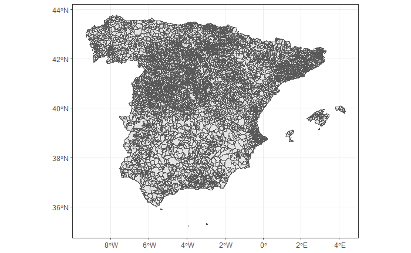

```r
peninbal_shp %>%
    ggplot() +
    geom_sf() +
    theme_bw()
```

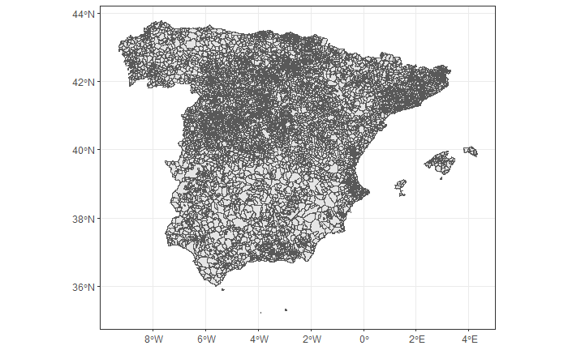

```r
peninbal_simpl_shp <-
    peninbal_shp %>%
    st_simplify(dTolerance = 1e-04)

canarias_simpl_shp <-
    canarias_shp %>%
    st_simplify(dTolerance = 1e-04)

peninbal_simpl_shp %>%
    ggplot() +
    geom_sf() +
    theme_bw()
```

The next thing we would like to do is to combine both sf-tibbles, so that the Peninsula, Balearics, and the Canary Islands all show up in a single map. Again, this is a simple task within the sf package: just use the rbind function to append the rows of one dataset to the other. However, we must first adjust the coordinate reference system, or CRS. The polygons of the Canary Islands have coordinates with respect to a CRS that is different from the one used by the coordinates of the Peninsula and Balearics. If we want to combine them, we must first transform the coordinates of one of them to the CRS of the other.

```r
# Transform Canary Islands to use the coordinate reference system (CRS) of the peninsula-balearics.
# This is a necessary step before unioning because peninsula-balearics and canarias have
# different CRS.
canarias_transformed_shp <-
    canarias_simpl_shp %>%
    st_transform(st_crs(peninbal_simpl_shp))

# Union peninsula-balearics + canarias
espana_shp <- rbind(peninbal_simpl_shp, canarias_transformed_shp)
```

Once combined, the final result is the following:

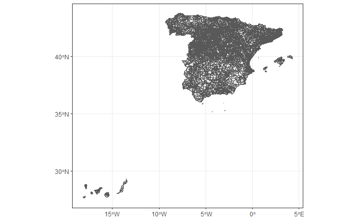

```r
espana_shp %>%
    ggplot() +
    geom_sf() +
    theme_bw()
```

# 2.Loading the occurrance data:

```r
fields <- c("key",
            "decimalLatitude",
            "decimalLongitude",
            "family",
            "species")



quercus <- occ_search(country = "ES",
                      datasetKey = "fab4c599-802a-4bfc-8a59-fc7515001bfa",
                      familyKey = 4689,
                      fields = fields,
                      limit  = 80000)
quercus_data <- quercus$data


pastos <- occ_search(country = "ES",
                     datasetKey = "4cf3eec1-b902-40c9-b15b-05c5fe5928b6",
                     familyKey = 3073,
                     fields = fields,
                     limit = 100000)

pastos_data <- pastos$data

fagaceae_sf <-
  st_as_sf(quercus_data[1:10000,],
           coords = c("decimalLongitude", "decimalLatitude"),
           crs = 4326
  )
```

Put both quercus and pastos dataframes together:

```r
occurrances_df <- bind_rows(quercus_data, pastos_data)
```

```r
pnts <- occurrances_df[c("decimalLongitude","decimalLatitude")] #Dataframe just with the coordinates of occ
# create a points collection
pnts_sf <- do.call("st_sfc",c(lapply(1:nrow(pnts),
function(i) {st_point(as.numeric(pnts[i, ]))}), list("crs" = 4326)))

pnts_trans <- st_transform(pnts_sf, 2163) # apply transformation to pnts sf
espana_shp_trans <- st_transform(espana_shp, 2163)      # apply transformation to polygons sf

# intersect and extract municipality name
occurrances_df$region <- apply(st_intersects(espana_shp_trans, pnts_trans, sparse = FALSE), 2,
               function(col) {
                  espana_shp_trans[which(col),]$NATCODE
               })

#The above line returns a column of type list of char objects, let's make it a string column
occurrances_df <- occurrances_df %>%
  mutate(region = sapply(region, toString))
```

# 3. Corpus creation and layout preparation

We now create the “documents” that we will use in our LDA. Each municipality makes a document with a set of “words” (each occurrence is a word - the name of the species observed).

```r
documents_df <- occurrances_df %>%
  group_by(region, species) %>%
  add_count(name = "Count") %>%
  distinct(species, .keep_all = TRUE)

documents_df$species <- lapply(documents_df$species, gsub, pattern = " ", replacement = "-", fixed = TRUE)#Replace spaces in "species" column for "-".

documents_df$word <- paste(documents_df$family,documents_df$species,sep= "-") #Create a "word" column that concatenates family and species name

documents_df$speech <- apply(documents_df, 1, function(x) paste(replicate(x$Count, x$word), collapse = " ")) #Create the speech column repeating the word (species) by count (the amount of times it was observed). Note that this is not yet the final speech, we have to group them by region to have all words in that document (region).

#Group by region and get the full speech (the concatenation of species seen in that region)
documents_df <- documents_df %>%
  group_by(region) %>%
  summarise(full_speech = paste(speech, collapse = " "))
```

```r
head(documents_df)
```

[output not shown]

Let’s inspect the lenght of each document:

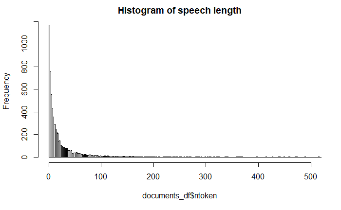

```r
documents_df$ntoken <- ntoken(documents_df$full_speech)
hist(documents_df$ntoken, main = "Histogram of speech length", xlim = c(0, 500), breaks = 1000)
```

```r
#Create corpus:
speeches_Corpus <- corpus(documents_df, docid_field = 'region', text_field = 'full_speech')
summary(speeches_Corpus, 5)
```

```
Corpus consisting of 6270 documents, showing 5 documents:

        Text Types Tokens Sentences ntoken
 34010404001     8     16         1     16
 34010404002     3     23         1     23
 34010404003     7     24         1     24
 34010404005     9     17         1     17
 34010404006     4      4         1      4
```

```r
#Filtering doc lenght:
ntokens_corpus <- ntoken(speeches_Corpus)
docs_length15 <- names(ntokens_corpus[(ntokens_corpus>=15)])
speeches_Corpus <- speeches_Corpus[names(speeches_Corpus) %in% docs_length15]

#Print summary:
summary(speeches_Corpus, n=4)
```

```
Corpus consisting of 2466 documents, showing 4 documents:

        Text Types Tokens Sentences ntoken
 34010404001     8     16         1     16
 34010404002     3     23         1     23
 34010404003     7     24         1     24
 34010404005     9     17         1     17
```

```r
head(speeches_Corpus)
```

```
Corpus consisting of 6 documents and 1 docvar.
34010404001 :
"Fagaceae-Quercus-rotundifolia Fagaceae-Quercus-rotundifolia ..."

34010404002 :
"Fagaceae-Quercus-rotundifolia Fagaceae-Quercus-rotundifolia ..."

34010404003 :
"Poaceae-Cynodon-dactylon Poaceae-Cynodon-dactylon Poaceae-Cy..."

34010404005 :
"Fagaceae-Quercus-rotundifolia Fagaceae-Quercus-rotundifolia ..."

34010404019 :
"Fagaceae-Quercus-rotundifolia Fagaceae-Quercus-rotundifolia ..."

34010404029 :
"Fagaceae-Quercus-rotundifolia Fagaceae-Quercus-rotundifolia ..."
```

# Turn this corpus into a document-feature matrix.

```r
custom_list_remove <- c("fagaceae-quercus-rotundifolia") #List of words to be removed

speechDFM_filtered <- tokens(speeches_Corpus) %>%
                      tokens_remove(custom_list_remove) %>%
                      dfm() %>%
                      dfm_tolower() %>%
                      dfm_trim(min_termfreq = 5, min_docfreq = 0.0025, docfreq_type = "prop")
speechDFM_filtered <- dfm_subset(speechDFM_filtered, ntoken(speechDFM_filtered) > 0) #Rmove any empty document
speechDFM_filtered
```

```
Document-feature matrix of: 2,448 documents, 394 features (95.37% sparse) and 1 docvar.
             features
docs          poaceae-bromus-rigidus poaceae-dactylis-glomerata poaceae-echinaria-capitata
  34010404001                      1                          1                          1
  34010404002                      0                          0                          0
  34010404003                      0                          0                          0
  34010404005                      1                          0                          0
  34010404019                      0                          0                          1
  34010404029                      0                          0                          0
             features
docs          poaceae-phragmites-australis poaceae-achnatherum-miliaceum poaceae-saccharum-ravennae
  34010404001                            1                             2                          1
  34010404002                            0                             0                          0
  34010404003                            7                             0                          2
  34010404005                            1                             2                          1
```

[output cut: 19 more lines]

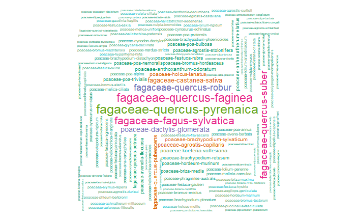

```r
textplot_wordcloud(speechDFM_filtered, random_order = FALSE, rotation = 0.25,
    color = RColorBrewer::brewer.pal(8, "Dark2"))
```

With the function `topfeatures` we can extract the most frequent terms in our document$\times$term frequency matrix.

```r
topfeatures(speechDFM_filtered, 20)
```

```
     fagaceae-quercus-coccifera      fagaceae-quercus-pyrenaica        fagaceae-quercus-faginea
                           9666                            5428                            4710
       fagaceae-fagus-sylvatica          fagaceae-quercus-suber          fagaceae-quercus-robur
                           4134                            3846                            3438
     poaceae-dactylis-glomerata        fagaceae-castanea-sativa      fagaceae-quercus-pubescens
                           2465                            2191                            1652
    poaceae-agrostis-capillaris poaceae-brachypodium-sylvaticum          poaceae-holcus-lanatus
                           1461                            1389                            1312
    poaceae-koeleria-vallesiana   poaceae-arrhenatherum-elatius   poaceae-anthoxanthum-odoratum
                           1203                            1185                            1171
       fagaceae-quercus-petraea    poaceae-brachypodium-retusum       poaceae-bromus-hordeaceus
                           1157                            1151                            1116
          poaceae-festuca-rubra       poaceae-avenella-flexuosa
                           1112                            1046
```

## TF-IDF

Latent Dirichlet Allocation takes as input a document$\times$term frequency matrix. However, another popular representation of a corpus is a TF-IDF matrix which has the same structure as a document$\times$term frequency matrix but the term frequencies (TF) are weighted by the inverse document frequency (IDF). The IDF is the inverse of the number of documents in which the term occurs, log scaled. The objective is to downscale the matrix entries of frequent terms in the corpus and upscale the matrix entries of terms specific to a group of documents.

```r
speechDFM_filtered_tfidf <- tokens(speeches_Corpus) %>%
                      tokens_remove(custom_list_remove) %>%
                      dfm() %>%
                      dfm_tolower() %>%
                      dfm_trim(min_termfreq = 5, min_docfreq = 0.0025, docfreq_type = "prop") %>%
                      dfm_tfidf()
speechDFM_filtered_tfidf
```

```
Document-feature matrix of: 2,466 documents, 394 features (95.40% sparse) and 1 docvar.
             features
docs          poaceae-bromus-rigidus poaceae-dactylis-glomerata poaceae-echinaria-capitata
  34010404001               1.071847                  0.5450377                  0.9703891
  34010404002               0                         0                          0
  34010404003               0                         0                          0
  34010404005               1.071847                  0                          0
  34010404019               0                         0                          0.9703891
  34010404029               0                         0                          0
             features
docs          poaceae-phragmites-australis poaceae-achnatherum-miliaceum poaceae-saccharum-ravennae
  34010404001                     0.892306                      2.119109                   1.701797
  34010404002                     0                             0                          0
  34010404003                     6.246142                      0                          3.403594
  34010404005                     0.892306                      2.119109                   1.701797
```

[output cut: 19 more lines]

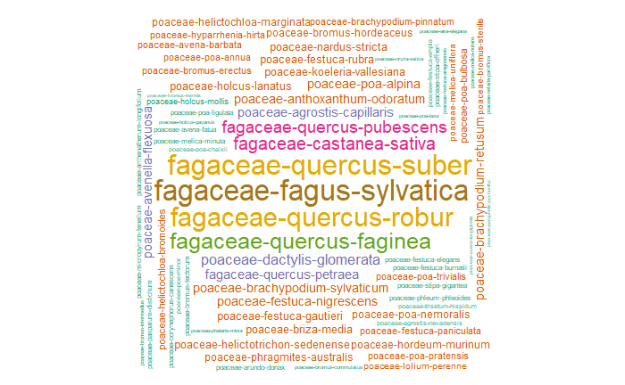

```r
textplot_wordcloud(speechDFM_filtered_tfidf, random_order = FALSE, rotation = 0.25,
    color = RColorBrewer::brewer.pal(8, "Dark2"))
```

# Latent Dirichlet Allocation

Now that have our corpus representation ready we can run our topic models. In `R` there are several packages implementing topic models. In this seminar will we use the `lda` package that implements a collapsed Gibbs sampling for Latent Dirichlet Allocation (LDA) and supervised LDA. Another package is `topicmodels` that implements Latent Dirichlett Allocation and Correlated Topic Models estimated with a variational expectation-maximization algorithm or Gibbs sampling.

We convert our corpus to an object that has the format required by package `lda`. We use the function `convert` from `quanteda` to do that.

```r
# convert to lda format
library(tm)
biodiversity_lda <- convert(speechDFM_filtered, to = "lda")
```

We estimate our LDA model. We need to set the number of topics $K$, the number of iterations $G$, and Dirichlet priors hyperparameters.

```r
# MCMC and model tuning parameters:
K <- 8 # number of topics
G <- 2000 # number of iterations
eta <- 1/K # Dirichlet hyperparamater for topic multinomials
alpha <- 1/K # Dirichlet hyperparameter for topic proportions

# fit the model
t1 <- Sys.time()
lda_fitted <- lda.collapsed.gibbs.sampler(documents = biodiversity_lda$documents, K = K,
                                   vocab = biodiversity_lda$vocab,
                                   num.iterations = G, alpha = alpha,
                                   eta = eta, initial = NULL, burnin = 0,
                                   compute.log.likelihood = TRUE)
t2 <- Sys.time()
t2 - t1
```

```
Time difference of 13.06327 secs
```

We can use the function `top.topic.words` to extract the top words by topic, that is the most probable words in each topic.

```r
top.topic.words(lda_fitted$topics,num.words=20)
```

```
      [,1]                                [,2]                              [,3]                                [,4]
 [1,] "fagaceae-quercus-coccifera"        "fagaceae-quercus-pyrenaica"      "poaceae-dactylis-glomerata"        "fagaceae-quercus-robur"
 [2,] "fagaceae-quercus-faginea"          "poaceae-helictochloa-marginata"  "poaceae-brachypodium-retusum"      "fagaceae-castanea-sativa"
 [3,] "fagaceae-quercus-pubescens"        "fagaceae-quercus-faginea"        "poaceae-phragmites-australis"      "fagaceae-fagus-sylvatica"
 [4,] "fagaceae-quercus-petraea"          "poaceae-dactylis-glomerata"      "poaceae-brachypodium-distachyon"   "fagaceae-quercus-pyrenaica"
 [5,] "poaceae-avena-sativa"              "poaceae-glyceria-declinata"      "poaceae-hordeum-murinum"           "fagaceae-quercus-petraea"
 [6,] "poaceae-festuca-gracilior"         "poaceae-agrostis-castellana"     "fagaceae-quercus-coccifera"        "poaceae-arrhenatherum-longifolium"
 [7,] "poaceae-poa-compressa"             "poaceae-aira-caryophyllea"       "poaceae-cynodon-dactylon"          "poaceae-agrostis-curtisii"
 [8,] "poaceae-glyceria-notata"           "poaceae-arrhenatherum-elatius"   "poaceae-avena-barbata"             "poaceae-holcus-mollis"
 [9,] "poaceae-festuca-paniculata"        "poaceae-trisetaria-ovata"        "poaceae-bromus-hordeaceus"         "poaceae-agrostis-capillaris"
[10,] "poaceae-achnatherum-calamagrostis" "poaceae-holcus-lanatus"          "poaceae-agrostis-stolonifera"      "fagaceae-quercus-suber"
[11,] "poaceae-festuca-marginata"         "poaceae-periballia-involucrata"  "poaceae-hyparrhenia-hirta"         "poaceae-holcus-lanatus"
[12,] "poaceae-puccinellia-fasciculata"   "poaceae-bromus-hordeaceus"       "poaceae-brachypodium-phoenicoides" "poaceae-agrostis-durieui"
[13,] "poaceae-arrhenatherum-elatius"     "poaceae-brachypodium-sylvaticum" "poaceae-catapodium-rigidum"        "poaceae-anthoxanthum-odoratum"
[14,] "poaceae-festuca-gautieri"          "poaceae-poa-bulbosa"             "poaceae-lolium-rigidum"            "fagaceae-quercus-rubra"
```

[output cut: 27 more lines]

We can use the function `top.topic.documents` to extract the top documents by topic, that is the documents most associated with each topic.

```r
top_docs <- top.topic.documents(lda_fitted$document_sums, num.documents = 5)
```

Next, we obtain the D×K community proportions matrix where we get the proportion of each topic assigned to each sample unit.

```r
thetas <- as.data.frame(t(lda_fitted$document_sums), row.names= speechDFM_filtered@docvars[["docname_"]])
thetas <- thetas/rowSums(thetas)
thetas$NATCODE <- row.names(thetas)
```